# ENEM 2025: desigualdade de notas por rede de ensino, perfil socioeconômico e PIB regional

Moises da Conceição dos Santos

outubro de 2026

## Resumo

- **Pergunta:** como as notas do ENEM 2025 variam entre redes de ensino e territórios, e quanto dessa variação é explicada pela riqueza da região (PIB) e pelo perfil socioeconômico dos alunos?
- **Rede de ensino:** entre os 1.288.485 concluintes de 2025 presentes nos dois dias, a nota geral média na rede **privada** (610) é **113 pontos** maior que na **estadual** (497). A rede **federal** (584) fica bem mais perto da privada que da estadual.
- **Território:** o PIB per capita sozinho explica 55% da variação das notas entre as regiões imediatas. O **perfil socioeconômico dos alunos** explica **86%**. Com o perfil no modelo, o PIB acrescenta pouco: o R² passa de 86% para 88%.
- **A vantagem da rede privada encolhe nas regiões mais ricas:** dobrar o PIB per capita está associado a uma diferença privada − estadual 8 pontos menor.
- **Há regiões que superam o esperado** para o seu perfil, como o Sertão da Paraíba e de Pernambuco, e outras muito abaixo, como o interior do Amazonas. Elas são candidatas naturais a estudos de caso.
- **Além da média:** a renda média da região explica melhor as notas dos alunos de **nota baixa** (R² de 81%) do que as de **nota alta** (67%). A inclinação, porém, não é estatisticamente diferente entre os dois grupos.
- **Escolaridade da mãe:** nas regiões, ela é praticamente inseparável da renda (correlação de 0,91). Com as duas no mesmo modelo, prevalece a renda. Isso não confirma nem refuta a literatura, que trabalha com dados individuais.

## Observação: o que a LGPD limita e o que ela protege

Esta análise foi desenhada em torno de uma restrição imposta pela Lei Geral de Proteção de Dados (Lei nº 13.709/2018). Vale explicar a restrição antes dos resultados, porque ela define o que este relatório pode e o que não pode afirmar.

**O que a LGPD limitou nos microdados do ENEM**

Desde 2020, o INEP adota um modelo simplificado de microdados. Na edição de 2025, isso significa que:

- os arquivos de **notas** e de **questionário socioeconômico** são publicados **separados, sem chave em comum**. Não é possível saber a renda, a cor/raça ou a escolaridade dos pais de quem tirou cada nota;
- o **município de residência** e o de nascimento foram retirados. Resta apenas o município onde a prova foi feita;
- a **idade exata** foi substituída por faixas etárias;
- o **código da escola** é mascarado quando ela tem menos de 10 participantes;
- provas aplicadas a **grupos muito pequenos** foram excluídas da base.

Para a pesquisa, o custo é real. Perguntas clássicas, como “quanto a renda da família explica a nota do aluno?”, não podem mais ser respondidas com os dados de 2025. Por isso, este relatório trabalha com **regiões**, e não com indivíduos, e por isso usa a **renda média da região**, e não a renda de cada família.

**O que a LGPD resguardou**

- **Proteção de quase 5 milhões de pessoas, muitas delas menores de idade.** Em um município pequeno, a combinação de escola, faixa etária, sexo e cor/raça pode apontar para um único estudante. Ligar essa pessoa à sua nota e à renda declarada da família exporia informações que ela forneceu ao Estado com outra finalidade. O próprio INEP relata ter encontrado evidências concretas de que o código da escola facilitava a identificação indevida de participantes.
- **Proteção de dados sensíveis.** Cor/raça é dado sensível pela LGPD (art. 5º, II), e renda e condições de moradia expõem a situação econômica da família.
- **Confiança no questionário.** O questionário socioeconômico só tem valor se os participantes responderem com sinceridade, e isso depende de confiarem que as respostas não serão expostas.
- **Menos rankings enganosos.** O INEP deixou de divulgar o “ENEM por Escola” desde 2015 e não recomenda usar os microdados para ranquear escolas, que costumam medir mais o perfil dos alunos do que a qualidade do ensino. A seção 4 deste relatório mostra justamente o peso desse perfil.

**O equilíbrio possível.** A lei não fechou os dados: ela mudou a forma de usá-los. Este relatório mostra que, com agregação territorial, ainda é possível produzir evidência relevante para políticas públicas sem expor nenhum participante. O preço é a cautela nas conclusões, explicitada ao longo do texto e na seção 11.

## 1. Dados e desenho

| Fonte | Conteúdo | Nível |
| --- | --- | --- |
| INEP: microdados do ENEM 2025 | Notas, rede e localização da escola (arquivo *Resultados*); perfil e questionário socioeconômico (arquivo *Participantes*) | Participante |
| IBGE: PIB dos Municípios (SIDRA 5938) | PIB a preços correntes, 2023 | Município |
| IBGE: Censo 2022 (SIDRA 4709) | População residente | Município |
| IBGE: API de Localidades | Município → região geográfica imediata | Município |
| IPEA: pacote `geobr` | Malhas das regiões imediatas e das UFs | Região |

**O desafio: as bases do INEP não se conectam.** Para cumprir a LGPD, o INEP divulga os arquivos de participantes e de resultados **sem chave em comum**. Não é possível saber a renda de quem tirou cada nota. A solução foi usar o **território como ponte**: cada base é agregada por região e só depois cruzada.

```
Resultados (notas, rede)   ─► por região imediata ─┐
Participantes (perfil)     ─► por região imediata ─┼─► base regional
IBGE (PIB 2023, pop. 2022) ─► por região imediata ─┘   (507 regiões)
```

**Por que usar a região imediata, e não o município?** O participante só tem o município **onde fez a prova**. O INEP não divulga mais o município de residência, e a prova é aplicada em cerca de 1.800 cidades-polo. As 510 **regiões geográficas imediatas** do IBGE são justamente uma cidade-polo e os municípios que dependem dela, o que corresponde bem à geografia dos locais de prova.

**População comparável: concluintes de 2025.** Treineiros e egressos variam muito de região para região. Por isso, as duas bases foram restringidas aos concluintes do ensino médio em 2025:

- **Notas:** participantes com escola informada, vinculados pelo INEP ao Censo Escolar 2025 (1.739.028), localizados pelo município da **escola**. A análise usa os presentes nos dois dias.
- **Perfil:** participantes que declararam concluir o ensino médio em 2025 (1.811.344), localizados pelo município da **prova**.

As duas contagens são muito próximas: os vinculados ao Censo equivalem a 96% dos que se declararam concluintes. A ponte territorial liga, portanto, praticamente a mesma população.

**Nota geral:** média simples das quatro provas objetivas e da redação.

## 2. Panorama nacional

Dos 4.810.772 inscritos, **32,6%** faltaram ou foram eliminados em pelo menos um dos dias. Entre os presentes no 1º dia, **6,1%** tiveram nota zero na redação.

Redações que receberam nota zero, por motivo

| Situação | Participantes | % dos presentes |
| --- | --- | --- |
| Em branco | 114.329 | 3,31% |
| Cópia do texto motivador | 54.840 | 1,59% |
| Texto insuficiente | 16.975 | 0,49% |
| Fuga ao tema | 13.576 | 0,39% |
| Não atendimento ao tipo textual | 5.661 | 0,16% |
| Parte desconectada | 3.408 | 0,10% |
| Anulada | 3.070 | 0,09% |

A redação **em branco** é, de longe, o principal motivo. Esse é um sinal mais de desistência do que de desempenho.

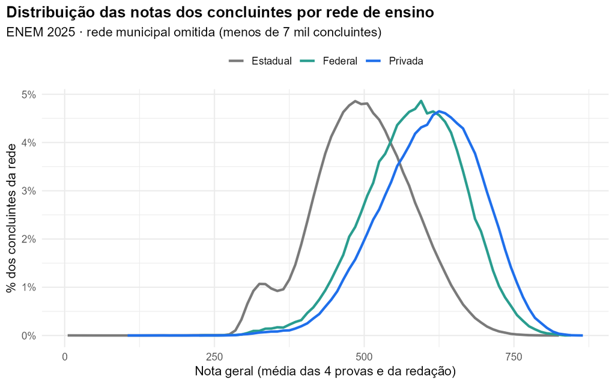

A distribuição da rede estadual tem um **segundo pico perto de 330 pontos**. Ele corresponde aos alunos com **redação zerada**: como a redação vale um quinto da nota geral, zerá-la derruba a média em cerca de 120 pontos. Esse grupo é muito menor nas redes federal e privada.

Nota geral média por rede e localização da escola

| Rede | Localização | Concluintes | Nota geral |
| --- | --- | --- | --- |
| Estadual | Rural | 50.610 | 467,0 |
| Estadual | Urbana | 910.718 | 498,8 |
| Federal | Rural | 8.690 | 561,9 |
| Federal | Urbana | 59.773 | 586,7 |
| Privada | Rural | 3.098 | 528,5 |
| Privada | Urbana | 248.994 | 611,5 |

A desigualdade também é **urbano-rural**: dentro de cada rede, as escolas rurais ficam de 25 (federal) a 83 pontos (privada) abaixo das urbanas.

## 3. Desigualdade entre redes, UF por UF

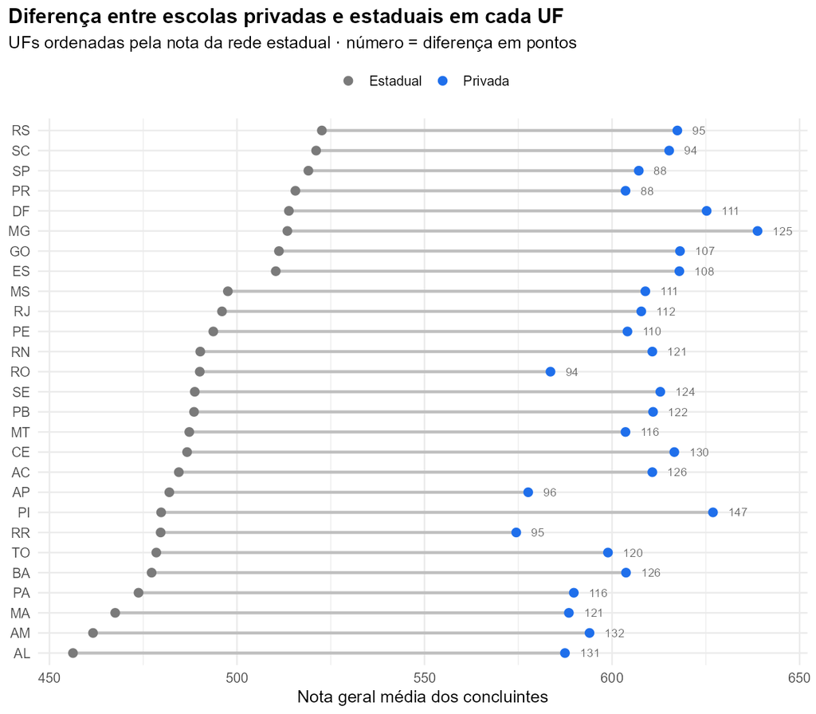

- A diferença entre privada e estadual vai de cerca de 88 pontos (SP e PR) a 147 pontos (PI).
- **Em todas as UFs**, a diferença passa de 85 pontos. Mesmo onde a rede estadual é mais forte (RS, SC, SP e PR), ela continua muito abaixo da privada.
- As **maiores diferenças** estão no Nordeste e no Norte: PI (147), AM (132), AL (131) e CE (130).

## 4. O que explica as diferenças entre regiões?

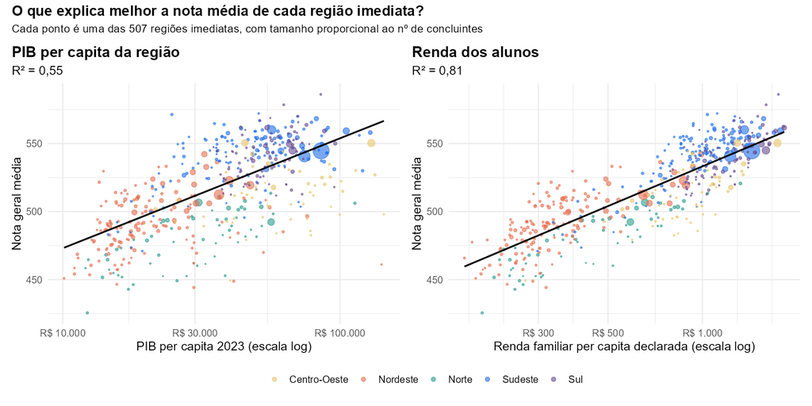

A nota média de cada região tem uma relação **muito mais forte com a renda das famílias dos alunos** do que com o **PIB per capita** da região. O PIB mede o que a região **produz**, e não quanto as famílias recebem. Em regiões com grande produção de minério, petróleo ou agronegócio, por exemplo, o PIB per capita fica alto enquanto a renda local continua baixa.

Modelo 1

Modelo 2

Modelo 3

Modelo 4

Modelo 5

log(PIB per capita)

35.080***

-13.075***

-13.082***

-6.651**

(2.472)

(3.105)

(3.190)

(2.180)

log(renda per capita dos alunos)

30.955***

38.776***

28.015***

15.994**

(6.176)

(5.953)

(6.280)

(4.346)

% mães com ensino superior

-1.389**

-1.319**

-1.295**

-0.232

(0.442)

(0.434)

(0.464)

(0.317)

% sem computador em casa

-0.815+

-0.980*

-1.075*

-0.936***

(0.452)

(0.395)

(0.422)

(0.209)

% pretos, pardos e indígenas

-0.206

-0.126

-0.136

-0.593**

(0.190)

(0.171)

(0.173)

(0.175)

% concluintes na rede privada

0.495***

0.303*

(0.129)

(0.112)

Num.Obs.

507

507

507

507

506

R2

0.551

0.861

0.875

0.886

0.952

- p < 0.1, * p < 0.05, ** p < 0.01, *** p < 0.001

Variável dependente: nota geral média da região imediata. Regressões ponderadas pelo nº de concluintes; erros-padrão agrupados por UF.

**Como ler a tabela**

- **Modelo 1:** sozinho, um PIB per capita **10% maior** está associado a uma nota **3,3 pontos** maior. Dobrar o PIB equivale a 24 pontos.
- **Modelo 2:** as quatro variáveis de perfil explicam 86% da variação entre regiões, muito mais que o PIB.
- **Modelos 3 e 4:** com o perfil no modelo (o 4 inclui também a % de concluintes na rede privada), o coeficiente do PIB **fica negativo**. Entre regiões com o mesmo perfil de alunos, ter PIB maior não está associado a notas maiores. Isso reforça que o que importa é a riqueza das famílias, e não a produção da região. No modelo 4, uma renda per capita dos alunos **10% maior** equivale a cerca de **2,7 pontos**.
- **Modelo 5:** com efeitos fixos de UF, a comparação é feita entre regiões da mesma UF, o que absorve diferenças de política estadual. As variáveis de perfil continuam relevantes.

**Cuidado:** as variáveis de perfil são muito correlacionadas entre si. Sinais isolados, como o coeficiente negativo de “% mães com ensino superior”, refletem essa colinearidade e não devem ser lidos um a um. A conclusão robusta é sobre o **conjunto** do perfil.

## 5. A vantagem da escola privada depende da riqueza da região?

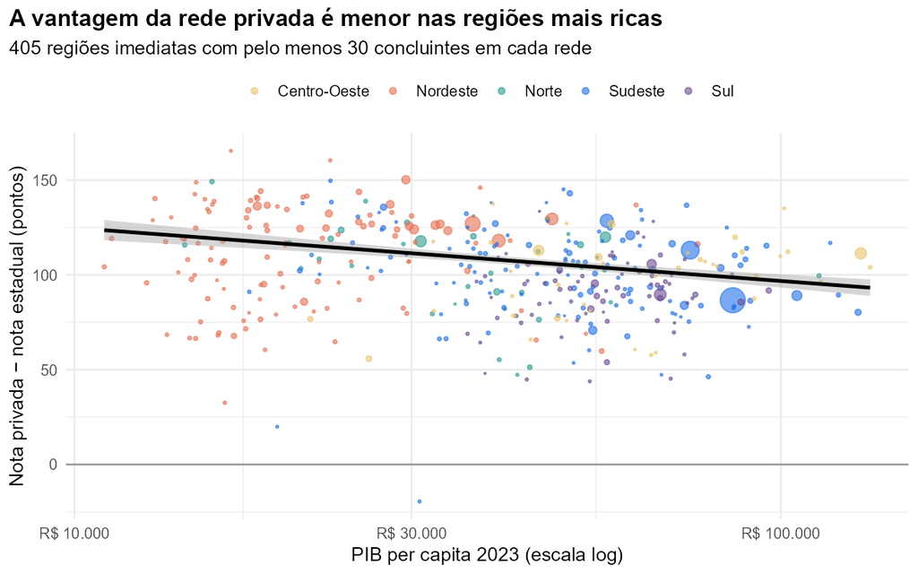

Nas 405 regiões com pelo menos 30 concluintes em cada rede, a diferença privada − estadual tem mediana de **103 pontos**. Ela **diminui** com o PIB per capita: dobrar o PIB está associado a uma diferença 8,4 pontos menor. Nas regiões mais pobres, a escola pública fica mais distante da privada.

## 6. Mapa da desigualdade e regiões fora do padrão

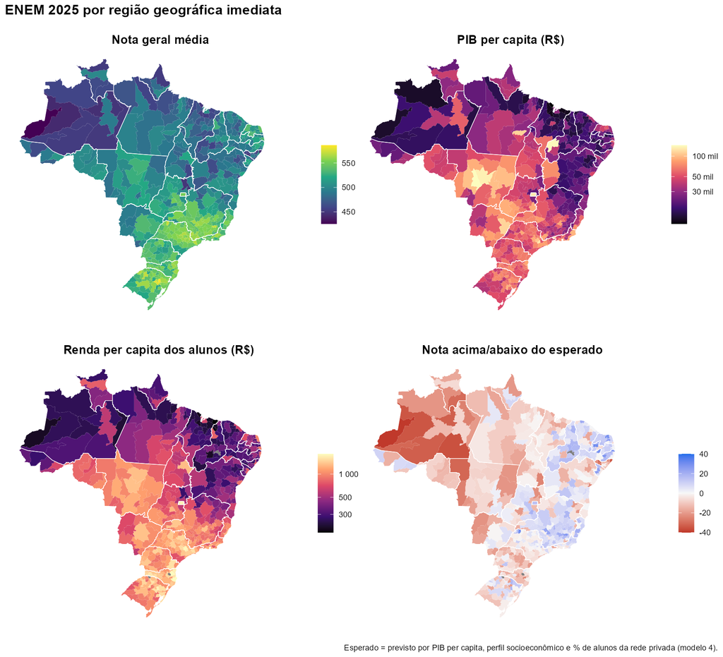

As notas seguem um claro **gradiente norte-sul**, quase idêntico ao da renda dos alunos. O mapa do canto inferior direito mostra o que **sobra** depois de descontar o PIB, o perfil dos alunos e a participação da rede privada (modelo 4):

- **Azul:** regiões com notas **acima do esperado**, que se concentram no Sertão nordestino e no interior de São Paulo e de Minas Gerais.
- **Vermelho:** regiões **abaixo do esperado**, com destaque para o interior do Amazonas.

10 regiões mais acima do esperado

| Região imediata | Concluintes | Renda pc (R$) | Nota observada | Nota esperada | Diferença |
| --- | --- | --- | --- | --- | --- |
| Sousa (PB) | 1.370 | 300 | 520,7 | 490,1 | 30,6 |
| Pombal (PB) | 548 | 289 | 513,0 | 482,5 | 30,5 |
| Fernandópolis (SP) | 548 | 1.115 | 572,1 | 541,7 | 30,4 |
| João Câmara (RN) | 616 | 384 | 508,4 | 478,6 | 29,8 |
| Afogados da Ingazeira (PE) | 1.797 | 329 | 521,6 | 492,5 | 29,0 |
| Goiana – Timbaúba (PE) | 2.713 | 325 | 503,0 | 474,2 | 28,8 |
| Belo Jardim – Pesqueira (PE) | 1.828 | 324 | 511,4 | 484,0 | 27,3 |
| Viçosa (MG) | 1.442 | 1.038 | 571,3 | 544,1 | 27,2 |
| Lagarto (SE) | 2.071 | 345 | 517,2 | 492,1 | 25,1 |
| Itabaiana (SE) | 1.981 | 424 | 522,5 | 498,2 | 24,3 |

10 regiões mais abaixo do esperado

| Região imediata | Concluintes | Renda pc (R$) | Nota observada | Nota esperada | Diferença |
| --- | --- | --- | --- | --- | --- |
| Tabatinga (AM) | 1.466 | 198 | 425,6 | 474,1 | -48,6 |
| Manicoré (AM) | 810 | 306 | 451,8 | 487,4 | -35,6 |
| Tefé (AM) | 1.273 | 253 | 442,9 | 477,4 | -34,6 |
| Porto Calvo - São Luís do Quitunde (AL) | 1.470 | 317 | 444,2 | 478,5 | -34,3 |
| Manacapuru (AM) | 1.114 | 268 | 446,3 | 479,1 | -32,8 |
| Lábrea (AM) | 632 | 310 | 453,2 | 485,9 | -32,7 |
| Juína (MT) | 501 | 918 | 491,8 | 522,9 | -31,1 |
| Eirunepé (AM) | 448 | 305 | 454,8 | 485,8 | -31,0 |
| Santana do Ipanema (AL) | 1.298 | 303 | 454,5 | 485,1 | -30,6 |
| Rorainópolis (RR) | 132 | 449 | 461,5 | 491,9 | -30,4 |

As regiões mais acima do esperado são **do interior do Nordeste** (PB, PE, RN e SE): têm renda per capita baixa e, mesmo assim, notas na média nacional. Esses são bons pontos de partida para investigar **políticas educacionais estaduais e municipais**, como a expansão do ensino integral. Esse resultado não prova que alguma política funcionou. Ele mostra onde vale a pena procurar.

## 7. Além da média: alunos de nota baixa e de nota alta

Até aqui, comparamos a **nota média** das regiões. Mas uma região pode ter média alta e, ainda assim, muitos alunos com nota muito baixa. Para olhar a distribuição inteira, calculamos em cada região os **quantis** da nota dos concluintes:

- **p10:** nota abaixo da qual estão os 10% de **nota mais baixa** da região;
- **p50:** a mediana;
- **p90:** nota acima da qual estão os 10% de **nota mais alta**.

Em seguida, estimamos, para cada quantil, a associação com o **PIB per capita** e com a **renda média da região**.

**Importante:** “renda média da região” é a média da renda per capita declarada pelos concluintes da região. **Não é a renda da família de cada aluno**, porque em 2025 a LGPD impede ligar a nota ao questionário de cada participante (veja a Observação).

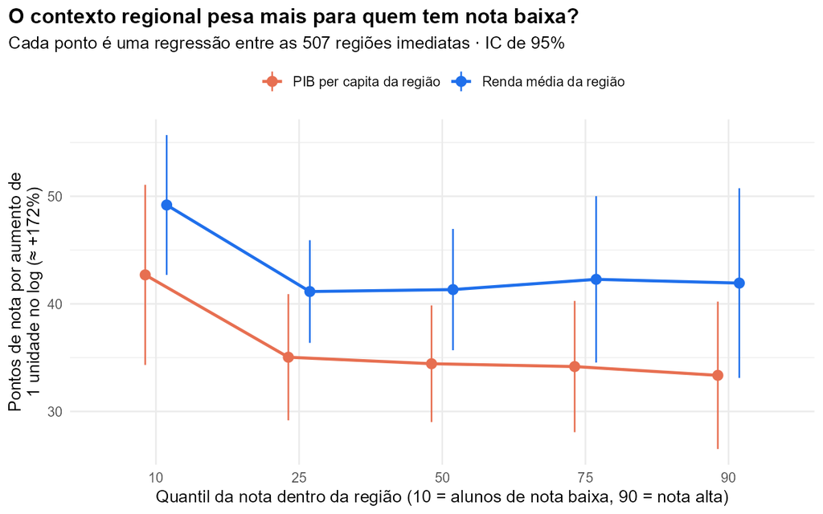

Associação da nota com o contexto regional, por quantil

| Preditor | Quantil | Coeficiente | Erro-padrão | R² |
| --- | --- | --- | --- | --- |
| PIB per capita | p10 | 42,7 | 4,3 | 0,60 |
| PIB per capita | p25 | 35,0 | 3,0 | 0,57 |
| PIB per capita | p50 | 34,4 | 2,8 | 0,53 |
| PIB per capita | p75 | 34,2 | 3,1 | 0,46 |
| PIB per capita | p90 | 33,4 | 3,5 | 0,42 |
| Renda média da região | p10 | 49,2 | 3,3 | 0,81 |
| Renda média da região | p25 | 41,1 | 2,4 | 0,80 |
| Renda média da região | p50 | 41,3 | 2,9 | 0,78 |
| Renda média da região | p75 | 42,3 | 3,9 | 0,72 |
| Renda média da região | p90 | 41,9 | 4,5 | 0,67 |

Teste formal: a associação é diferente para nota baixa e nota alta?

| Preditor | Diferença p90 − p10 | Erro-padrão | p-valor |
| --- | --- | --- | --- |
| Renda média da região | -7,3 | 6,2 | 0,25 |
| PIB per capita | -9,3 | 5,7 | 0,11 |

**Como ler:**

- **A inclinação é parecida em toda a distribuição.** Os coeficientes do p10 são um pouco maiores, mas a diferença em relação ao p90 **não é estatisticamente significativa** (p-valores de 0,25 e 0,11). Os dados **não permitem afirmar** que o contexto regional pesa mais para quem tem nota baixa.
- **O que muda é o poder explicativo.** O R² cai do p10 para o p90. As notas mais baixas de cada região são bem previstas pelo contexto regional, enquanto as mais altas dependem mais de fatores que a região não captura, como a escola e a trajetória individual de cada aluno.
- **As regiões sobem ou descem em bloco.** A distância entre p90 e p10 fica em torno de 224 pontos na maioria das regiões e quase não varia com a renda. Regiões mais ricas deslocam a distribuição inteira para cima, sem torná-la mais ou menos desigual por dentro.

**Nota de método:** como PIB e renda são medidos por região, este é o equivalente regional de uma regressão quantílica. Uma regressão quantílica com a renda de **cada família** exigiria dados individuais ligados, que a edição de 2023 do ENEM ainda oferecia (seção 9).

## 8. Escolaridade da mãe: o que dá e o que não dá para afirmar

Estudos com dados individuais costumam apontar a **escolaridade da mãe** como um dos preditores mais fortes do desempenho escolar, às vezes mais forte que a renda. Testamos o que é possível testar com os dados de 2025.

Quanto cada variável explica da nota média das regiões

| Modelo | R² |
| --- | --- |
| Só renda média da região | 0,81 |
| Só % de mães com ensino superior | 0,63 |
| As duas juntas | 0,82 |

Sem EF de UF

Com EF de UF

Renda média da região (padronizada)

1.065***

0.787***

(0.127)

(0.119)

% de mães com ensino superior (padronizada)

-0.241*

-0.075

(0.094)

(0.102)

Num.Obs.

507

506

R2

0.823

0.917

- p < 0.1, * p < 0.05, ** p < 0.01, *** p < 0.001

Variáveis padronizadas: coeficientes em desvios-padrão. EP agrupados por UF.

**O que os dados mostram:**

- Nas regiões, renda e escolaridade da mãe andam praticamente juntas (correlação de 0,91).
- Sozinha, a renda explica mais (81%) do que a escolaridade da mãe (63%).
- Com as duas juntas, a renda mantém o efeito e a da mãe some ou fica negativa. Com correlação tão alta, porém, esse sinal isolado é instável e não deve ser interpretado.

**Por que isso não contradiz a literatura:**

1. **Nível de análise.** A literatura compara alunos, e nós comparamos regiões. Uma relação forte entre alunos pode desaparecer no agregado.
2. **Medida grosseira.** A “% de mães com ensino superior” só capta o topo da escolaridade. No Brasil, boa parte da diferença está entre mães que completaram ou não o ensino fundamental e o médio.
3. **Colinearidade.** Com duas variáveis quase idênticas entre regiões, os dados não conseguem separar o peso de cada uma.

**Conclusão desta seção:** com os dados de 2025, **não é possível afirmar** que a escolaridade da mãe pesa mais que a renda. Afirmá-lo seria uma inferência sem base nestes dados. O teste adequado exige dados individuais (seção 9).

## 9. Próximo passo: escolaridade da mãe × infraestrutura urbana

Uma pergunta natural depois da seção 8 é se a **escolaridade da mãe** pesa mais nas notas do que as **condições urbanas** onde o aluno vive: mobilidade (tempo de deslocamento), condições ambientais (arborização e drenagem), condições habitacionais, serviços coletivos (água, esgoto e lixo) e infraestrutura (acessibilidade das vias). Essas são as cinco dimensões do Índice de Bem-Estar Urbano (IBEU), do Observatório das Metrópoles.

Essa análise **não foi feita neste relatório**. Esta seção registra como ela pode ser feita e como os resultados devem ser lidos.

**Os dados já estão disponíveis:**

- **ENEM 2023:** até essa edição, nota e questionário vinham no mesmo arquivo. Isso permite ligar a nota de cada aluno à escolaridade da mãe (Q002), à renda da família (Q006) e ao município da escola. Os microdados já foram baixados e conferidos.
- **Censo 2022 do IBGE:** a publicação *Características Urbanísticas do Entorno dos Domicílios* (abril de 2025) traz, por município, arborização, bueiro/drenagem, pavimentação, calçada, rampa, iluminação e ponto de ônibus. Os resultados do Censo 2022 também incluem abastecimento de água, esgoto e coleta de lixo. O IBEU municipal pronto só existe com o Censo 2010, por isso os índices precisariam ser recalculados com o Censo 2022.

**Como medir qual pesa mais:**

1. **Modelo multinível:** alunos agrupados por município. A escolaridade da mãe é medida no aluno, e a infraestrutura no município. O modelo separa quanto da variação das notas acontece dentro e entre municípios.
2. **Análise de dominância (decomposição de Shapley do R²):** divide o poder explicativo entre variáveis correlacionadas de forma justa, resolvendo o problema de colinearidade visto na seção 8.
3. **Validação fora da amostra:** mede quanto cada variável melhora a previsão em alunos que não foram usados para estimar o modelo.

**Como ler o resultado: o que dará e o que não dará para afirmar**

Se a análise mostrar que a escolaridade da mãe responde por uma parte maior do poder explicativo, **o que dará para afirmar** é que a escolaridade da mãe **explica mais** da variação das notas do que os índices de infraestrutura urbana.

**O que não dará para afirmar** é que melhorar a escolaridade das mães teria mais **impacto** nas notas do que melhorar o saneamento ou as vias. Fazer essa inferência diretamente a partir desses dados seria possível, mas incorreto. Nenhuma dessas variáveis foi sorteada, e “explicar mais variação” mede associação, não efeito causal. Para falar em impacto, seria preciso um desenho de avaliação de impacto, como os vistos no projeto experimental (RCT) deste portfólio.

## 10. Conclusões

1. **A desigualdade entre redes é grande e se repete em todo o país.** Os concluintes da rede estadual ficam em média cerca de 110 pontos atrás dos da rede privada. A rede federal mostra que uma escola pública pode chegar perto da privada.
2. **A renda das famílias explica mais que o PIB.** Políticas que usam o PIB per capita para focalizar recursos educacionais podem errar o alvo em regiões ricas em produção e pobres em renda.
3. **A escola pública é mais decisiva nas regiões pobres.** É nelas que a diferença em relação à rede privada é maior.
4. **Há espaço para aprender com regiões que superam o esperado**, sobretudo no interior do Nordeste.
5. **O contexto regional desloca a distribuição inteira.** Regiões mais ricas têm alunos de nota baixa e de nota alta com notas maiores, numa inclinação parecida.
6. **Próximo passo: dados individuais.** Até a edição de 2023, nota e questionário vinham no mesmo arquivo. Com eles, dá para testar a regressão quantílica com a renda de cada família e o peso da escolaridade da mãe aluno a aluno, inclusive em comparação com a infraestrutura urbana do Censo 2022 (seção 9).
7. **Explicar não é causar.** Mesmo que a escolaridade da mãe venha a explicar mais da variação das notas do que a infraestrutura urbana, isso não autoriza dizer que investir nela teria mais impacto. Essa distinção vale para todas as associações deste relatório.

## 11. Limitações

- **Análise ecológica:** as relações valem **entre regiões**. Não se pode concluir, a partir delas, que um aluno de família mais rica tira uma nota maior. As bases do INEP não permitem esse cruzamento individual.
- **Associação, não causalidade:** nenhuma variável foi sorteada, e os coeficientes descrevem correlações condicionais.
- **Geografias diferentes:** as notas estão no município da escola e o perfil no município da prova. As duas são levadas à região imediata, mas o encaixe não é perfeito. 3 regiões não têm local de prova e ficam fora dos modelos.
- **Renda autodeclarada e em faixas:** a renda per capita foi estimada pelo ponto médio de cada faixa e dividida pelo número de moradores.
- **Defasagem:** o PIB é de 2023 e a população é do Censo 2022. As notas são de 2025.
- **Seleção:** só concluintes que fizeram o ENEM entram na análise. Em regiões com menor taxa de inscrição, a amostra pode ser mais selecionada.

## Reprodutibilidade

Código completo em `R/`. Os microdados do INEP não estão no repositório (2,6 GB). Baixe-os em [gov.br/inep](https://www.gov.br/inep/pt-br/acesso-a-informacao/dados-abertos/microdados/enem) e rode `executar_tudo.R`.